# Extração de Conheciento de Bases Dados Biológicas Bipolar Disorder and Response to Lithium

Catarina Sousa pg32934 | Davide Lagoa pg31552 | João Silva a72023 José Morais pg32943 | Marta Moreno pg32847

12-06-2017

# 1 Introdução

> O lítio é um dos medicamentos mais eficazes no tratamento do **transtorno bipolar**, no entanto a resposta dos pacientes ao qual é administrado é bastante heterogénea. Apesar de se terem efetuado diversos estudos com esse fim, ainda não foram identificados biomarcadores que possam ser utilizados para monitorizar e prever a resposta ao tratamento com lítio. O estudo a ser analisado procura **avaliar os efeitos do lítio sobre a expressão génica** ao identificar alterações na expressão de genes específicos 1 mês após o início do tratamento, sendo essa informação utilizada para prever os resultados ao fim de 6 meses.

> Para o estudo foram recrutados 74 pacientes, sendo que 9 desistiram antes da primeira colheita de sangue e outros 5 apresentaram fraca qualidade ou quantidade insuficiente de RNA, pelo que não constam nos resultados. Os restantes **60 pacientes** foram **divididos em 2 grupos** criados aleatoriamente: um sujeito a tratamento com pelo menos um outro *medicamento que não lítio (OPT)*, e outro que fazia o tratamento anterior acoplado com a *toma de lítio (Li + OPT)*, sendo os grupos constituídos por 32 e 28 pacientes, respetivamente.

> Para o grupo *Li + OPT*, 62 genes apresentaram indução diferencial entre os pacientes que responderam ao tratamento e os que não responderam ao tratamento. Os pacientes do grupo *Li + OPT* que responderam ao tratamento apresentavam padrões distintos que não foram observados nos pacientes do grupo *OPT* com resposta ao tratamento, sendo que estes últimos eram mais parecidos com os pacientes do grupo *Li + OPT* sem resposta ao tratamento.

> Também foram realizados **testes utilizando RT-PCR** em tempo real de certos genes, tendo-se verificado que os resultados desta análise foram **similares aos obtidos com microarrays**, com os pacientes *Li + OPT* com resposta ao tratamento a demonstrarem uma maior indução desses genes do que os outros grupos. No entanto, com a exceção do gene *BCL2L1*, os resultados não foram estatisticamente significativos, o que corrobora o facto de que nos estudos com *microarrays* a maior diferença foi observada para *BCL2L1* (Beech et al. 2014).

# 2 Dados

> *Download* e carregamento do *DataSet* escolhido para o trabalho:

```r
gds <- getGEO('GDS5393', destdir=".")
```

> Conversão do *DataSet* para um *ExpressionSet*:

```r
data <- GDS2eSet(gds,do.log2=TRUE)
data
```

```
## ExpressionSet (storageMode: lockedEnvironment)
## assayData: 48107 features, 120 samples
##   element names: exprs
## protocolData: none
## phenoData
##   sampleNames: GSM1105438 GSM1105486 ... GSM1105456 (120 total)
##   varLabels: sample agent ... description (6 total)
##   varMetadata: labelDescription
## featureData
##   featureNames: ILMN_1343048 ILMN_1343049 ... ILMN_3311190 (48107
##     total)
##   fvarLabels: ID Gene title ... Platform_SEQUENCE (22 total)
##   fvarMetadata: Column labelDescription
## experimentData: use 'experimentData(object)'
##   pubMedIds: 23670706
## Annotation:
```

> Dimensão do *DataSet*:

```r
dim(data)
```

```
## Features  Samples
##    48107      120
```

> Conversão do *DataSet* para uma matiz numérica, contendo as *samples* nas colunas e as *features* nas linhas:

```r
exp = exprs(data)
class(exp)
```

```
## [1] "matrix"
```

```r
exp[5:15,1:5]
```

```
##              GSM1105438 GSM1105486 GSM1105487 GSM1105490 GSM1105491
## ILMN_1343059         NA         NA         NA         NA         NA
## ILMN_1343061         NA         NA         NA         NA         NA
## ILMN_1343062         NA         NA         NA         NA         NA
## ILMN_1343063         NA         NA         NA         NA         NA
## ILMN_1343064         NA         NA         NA         NA         NA
## ILMN_1343291   3.897076   3.879412   3.891526   3.899089   3.881381
## ILMN_1343295   3.597257   3.636949   3.642447   3.543385   3.582953
## ILMN_1343296         NA         NA         NA         NA         NA
## ILMN_1343297         NA         NA         NA         NA         NA
## ILMN_1343298         NA         NA         NA         NA         NA
## ILMN_1343299         NA         NA         NA         NA         NA
```

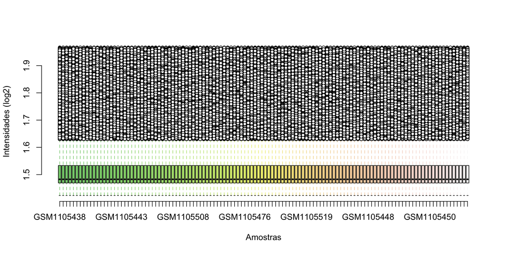

```r
col = terrain.colors(length(pData(data)$sample), alpha = 0.6)
dataBox = log2(exp)
boxplot(dataBox, col = col, whiskcol = col, pch = 21, cex = 0.8, xlab = 'Amostras', ylab = 'Intensidades (log2)', notch = TRUE, frame = FALSE)
```

## 2.1 Metadados

> Resumo do conteúdo do *DataSet:*

```r
abstract(data)
```

```
## [1] "Analysis of peripheral blood from patients with bipolar disorder before and 1 month after lithium treatment. Response of patients to lithium assessed after 6 months. Results identify a gene expression signature for the response to lithium treatment in patients with bipolar disorder."
```

> Exemplo para verificar o nome de algumas das amostras e identificadores dos genes:

```r
sampleNames(data)[1:10]
```

```
##  [1] "GSM1105438" "GSM1105486" "GSM1105487" "GSM1105490" "GSM1105491"
##  [6] "GSM1105495" "GSM1105498" "GSM1105499" "GSM1105506" "GSM1105442"
```

```r
featureNames(data)[1:8]
```

```
## [1] "ILMN_1343048" "ILMN_1343049" "ILMN_1343050" "ILMN_1343052"
## [5] "ILMN_1343059" "ILMN_1343061" "ILMN_1343062" "ILMN_1343063"
```

> De maneira a solidificar o nosso conhecimento sobre o *DataSet* em estudo é muito útil termos uma ideia dos atributos disponíveis.

```r
varMetadata(data)
```

```
##             labelDescription
## sample                  <NA>
## agent                   <NA>
## other                   <NA>
## time                    <NA>
## individual              <NA>
## description             <NA>
```

> A execução do comando anterior permitiu identificar no nosso *DataSet* os seguintes atributos, sendo que nenhum deles apresenta descrição:
- sample
- agent
- other
- individual
- description
- time

> Para aprofundar o nosso conhecimento sobre este *DataSet*, corremos os seguintes comandos de modo a organizar algumas ideias sobre os atributos disponíveis numa tabela.

```r
data$sample
data$agent
data$other
data$individual
data$description
data$time
```

**Tabela 1** - Informação contida no *DataSet* utilizado.

| Nome do Atributo | Significado | Valores Distintos | Valores Distintos |
| --- | --- | --- | --- |
| sample | Amostras Disponíveis | 120 | “GSM1105438” “GSM1105486”… |
| agent | Tipo de Tratamento | 2 | “control” “lithium” |
| other | Resposta ao Tratamento | 2 | “non-responder” “responder” |
| individual | Indivíduos em Análise | 60 | “Li+OPT_1” “Li+OPT_10”… |
| description | Descrição da amostra | 120 | NULL |
| time | Momento em que foi obtida a amostra | 2 | “1 month” “baseline” |

> Resposta dos diferentes grupos, *control* e *lithium* ao tratamento aplicado:

```r
addmargins(table(data$agent,data$other))
```

```
##
##           non-responder responder Sum
##   control            56         8  64
##   lithium            38        18  56
##   Sum                94        26 120
```

## 2.2 Tratamento dos Dados

> Verificação da existência de registos com valores omissos (*NA*) no *DataSet* :

```r
divisaoCI = c(sum(!complete.cases(exp)),sum(complete.cases(exp)))
divisaoCI
```

```
## [1]   784 47323
```

```r
sum(divisaoCI)
```

```
## [1] 48107
```

> Com a execução dos comandos anteriores verificamos que existem um total de 784 registos incompletos no *DataSet* e 47323 registos completos, fazendo assim um total de 48107, como esperado. De forma a tornar possível a análise dos dados, procedeu-se à remoção dos valores omissos.

```r
exp_complete=na.exclude(exp)
dim(exp_complete)
```

```
## [1] 47323   120
```

> Removendo os casos incompletos verificamos que, como era suposto, a dimensão do *DataSet* foi reduzida para 47323.

> Para verificar se os dados seguiam uma distribuição normal (0,1), calculámos a média e desvio padrão dos dados do nosso *DataSet* com os seguintes comandos:

```r
c(mean(exp_complete),sd(exp_complete))
```

```
## [1] 2.8839509 0.2084394
```

> Com isto verificamos que os dados não seguem uma distribuição normal (0,1). Pelo que se torna necessário normalizá-los recorrendo aos seguintes comandos:

```r
exp_norm=scale(exp_complete)
c(mean(exp_norm),sd(exp_norm))
```

```
## [1] 5.533452e-17 9.999895e-01
```

> Agora os nosso dados seguem aproximadamente uma distribuição normal (0,1), pelo que todas as análises posteriores serão feitas com base nos dados normalizados.

> De seguida, procurou-se remover os genes que possuíam valores pouco dispares ao longo das amostras, uma vez que não apresentam variabilidade significante para a distinção dos grupos amostrais. Para tal, procedeu-se à seleção dos genes cujo desvio padrão dos valores de expressão ao longo das amostras é duas vezes superior à mediana do desvio padrão de todos os genes.

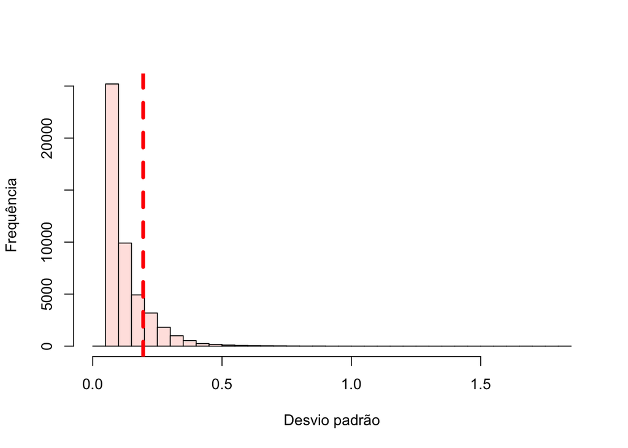

```r
sds=rowSds(exp_norm)
m=median(sds)
hist(sds,breaks=50,col='mistyrose',xlab = 'Desvio padrão',ylab = 'Frequência',main = NULL)
abline(v=m*2,col="red",lwd=4,lty=2)
```

```r
exp_filtrado=exp_complete[sds>=2*m,]
dim(exp_filtrado)
```

```
## [1] 7671  120
```

> Com este passo, reduziu-se os dados a utilizar nos passos seguintes para 7671 features.

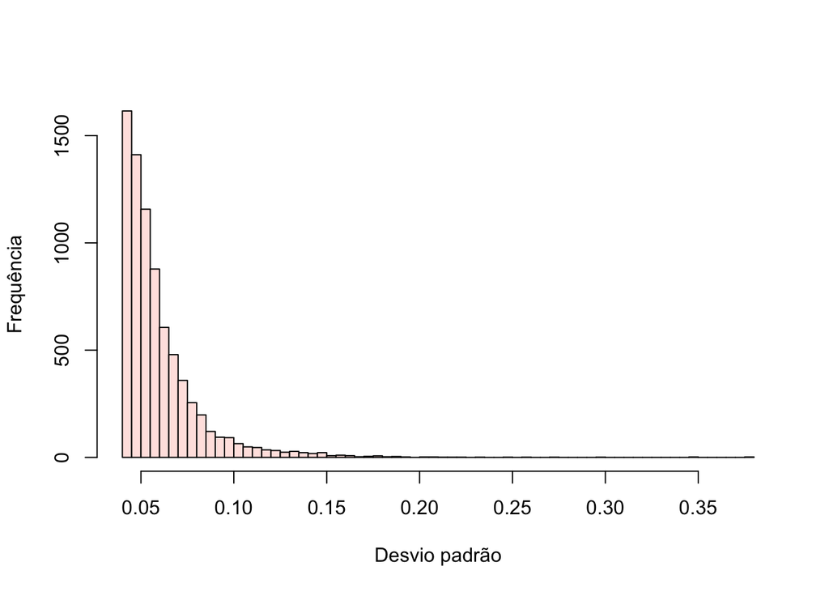

```r
hist(rowSds(exp_filtrado),breaks=50,col='mistyrose',xlab = 'Desvio padrão',ylab = 'Frequência',main = NULL)
```

> Aplicação do filtro *Flat Patterns* aos dados originais e criação de um novo *ExpressionSet* para guardar estes dados:

```r
exp_filtrado2=data[sds>=2*m,]
```

> Para realizarmos testes de hipóteses paramétricos (*t-test*) foi necessário normalizar o *ExpressionSet* (exp_filtrado2) utilizado, mantendo os filtros (remoção de valores omissos e aplicação de filtros *“Flat Patterns”*). Para tal, foi desenvolvida uma função que recebe um *ExpressionSet* com valores omissos, e uma lista com os nomes das linhas da matriz (que serão convertidos em índices), devolvendo um ExpressionSet sem os valores omissos.

```r
getFromExpression <- function(expressionFonte,valuesOK)
{
  j=1
  nomes = featureNames(expressionFonte)
  indicesValuesOK =c()
  for(i in 1:length(valuesOK)){
    nomeOK = valuesOK[i]
    indices = which( nomes== nomeOK)
    if(length(indices) > 0){
      indicesValuesOK[j] = indices
      j=j+1
    }
  }
  return(expressionFonte[indicesValuesOK,])
}
```

```r
exp_filtrado2_matrix = exprs(exp_filtrado2)
exp_filtrado2 = getFromExpression(exp_filtrado2,rownames(exp_filtrado2_matrix[complete.cases(exp_filtrado2_matrix),]))
exp_filtrado2_matrix = scale(exprs(exp_filtrado2))
c(mean(exp_filtrado2_matrix), sd(exp_filtrado2_matrix))
```

```
## [1] 5.638786e-17 9.999354e-01
```

```r
phenoData1=phenoData(exp_filtrado2)
featData1=featureData(exp_filtrado2)
expData1=experimentData(exp_filtrado2)
normalized_exp_filtrado2=ExpressionSet(assayData = exp_filtrado2_matrix, phenoData = phenoData1, featureData = featData1, experimentData = expData1)
c(mean(exprs(normalized_exp_filtrado2)),sd(exprs(normalized_exp_filtrado2)),sum(is.na(exprs(normalized_exp_filtrado2))))
```

```
## [1] 5.638786e-17 9.999354e-01 0.000000e+00
```

> O código acima apresentado, como é possivel verificar no *output* do último comando executado, é resposável pela remoção dos valores omissos e normalização do *ExpressionSet* a ser utilizado nos restantes passos.

# 3 Análise de Expressão Diferencial e de Enriquecimento

> Neste passo foram identificados, através de testes de hipóteses, os 25 genes que apresentavam menor *p-value*, ou seja, os genes cuja evidência estatística da expressão génica diferencial foi mais significativa. Os resultados obtidos foram registados nas tabelas seguintes e organizados segundo o nome do gene, identificador do gene e respetiva função.

## 3.1 Controlo x Lítio (1 mês de tratamento)

```r
test1=rowttests(normalized_exp_filtrado2[normalized_exp_filtrado2$time=="1 month"],"agent")
sign_pvalue1=test1[test1$p.value<0.01,]
pvalues1Signif=sign_pvalue1[order(sign_pvalue1$p.value),]
nomes1=rownames(pvalues1Signif)[1:25]
geneNames1=unlist(mget(nomes1, illuminaHumanv4SYMBOL))
geneFunction1=unlist(mget(nomes1, illuminaHumanv4GENENAME))
```

> Na seguinte tabela encontram-se os 25 genes com maior evidência estatística de expressão génica diferencial no que diz respeito ao atributo “agent”. Este teste foi feito com o intuito de perceber se, após 1 mês do tratamento em questão (com lítio), existem diferenças estatisticamente significativas na expressão dos genes. De facto, constatou-se que os respectivos *p-values* (*p-values* < 0.01) permitem rejeitar a hipótese nula, pelo que podemos assumir que os genes das amostras em condição de controlo e condição de tratamento com lítio são diferencialmente expressos. Numa primeira análise, isto pode indiciar uma influencia do lítio na expressão destes genes.

> A informação referente aos nomes dos genes e respetivas funções presente nas seguintes tabelas foi obtida com recurso à *API* disponível para *R* para fazer análise com amostras recolhidas através da *Illumina* (Dunning, Lynch, and Eldridge 2015).

**Tabela 2** - Os 25 Genes com maior expressão diferencial no teste estatístico entre os grupos Controlo e Lítio após 1 mês de tratamento.

| Nome do Gene | Nome da Variável | *p-value* | Função do Gene |
| --- | --- | --- | --- |
| GRHL1 | ILMN_1769934 | 7.684359e-05 | grainyhead like transcription factor 1 |
| CES1 | ILMN_2359945 | 1.634422e-04 | carboxylesterase 1 |
| POLI | ILMN_1702218 | 3.172987e-04 | DNA polymerase iota |
| CWF19L1 | ILMN_1651886 | 3.786476e-04 | CWF19-like 1, cell cycle control (S. pombe) |
| NA | ILMN_1905053 | 4.822311e-04 | NA |
| SNHG15 | ILMN_1898124 | 5.543943e-04 | small nucleolar RNA host gene 15 |
| SIGLEC10 | ILMN_1655549 | 7.699869e-04 | sialic acid binding Ig like lectin 10 |
| BHMT2 | ILMN_2070521 | 8.086180e-04 | betaine–homocysteine S-methyltransferase 2 |
| VPS33B | ILMN_1789243 | 8.274346e-04 | VPS33B, late endosome and lysosome associated |
| TSPAN12 | ILMN_1768115 | 8.607727e-04 | tetraspanin 12 |
| MCM3AP | ILMN_1784766 | 8.890522e-04 | minichromosome maintenance complex component 3 associated protein |
| SNORD91B | ILMN_3242443 | 9.608578e-04 | small nucleolar RNA, C/D box 91B |
| MICALCL | ILMN_1743232 | 1.147565e-03 | MICAL C-terminal like |
| NOTCH2 | ILMN_1777845 | 1.270860e-03 | notch 2 |
| NA | ILMN_3187754 | 1.377986e-03 | NA |
| CPZ | ILMN_1705258 | 1.533117e-03 | carboxypeptidase Z |
| NA | ILMN_1810104 | 1.730389e-03 | NA |
| CALD1 | ILMN_1730487 | 1.752684e-03 | caldesmon 1 |
| NCARD17 | ILMN_3238525 | 2.002094e-03 | caspase recruitment domain family member 17 |
| GIMAP8 | ILMN_1747305 | 2.159016e-03 | GTPase, IMAP family member 8 |
| TRPM2 | ILMN_2352380 | 2.188820e-03 | transient receptor potential cation channel subfamily M member 2 |
| NCOA4 | ILMN_1773906 | 2.199297e-03 | nuclear receptor coactivator 4 |
| SP140L | ILMN_1658858 | 2.211787e-03 | SP140 nuclear body protein like |
| PTH | ILMN_2202048 | 2.467427e-03 | parathyroid hormone |
| NA | ILMN_1898268 | 2.518019e-03 | NA |

**Análise de enriquecimento para os genes diferencialmente expressos**

> Após a realização do *t-teste*, procedeu-se à análise de enriquecimento a fim de obtermos os termos GO associados aos genes mais diferencialmente expressos.

```r
filtrados1 = featureNames(normalized_exp_filtrado2)
entrezID1= unlist(mget(filtrados1, illuminaHumanv4ENTREZID))
pvalue1= test1$p.value<0.01
pvalFilt = normalized_exp_filtrado2[pvalue1,]
entrezIdSel1 = unlist(mget(featureNames(pvalFilt), illuminaHumanv4ENTREZID))
GO1 = new("GOHyperGParams", geneIds=entrezIdSel1, universeGeneIds=entrezID1, annotation="illuminaHumanv4.db", ontology="BP", pvalueCutoff=0.025, testDirection="over")
GO1_= hyperGTest(GO1)
```

> Na seguinte tabela, estão presentes os quinze termos *GO* com maior associação ao atributo *agent* (controlo/lítio), ao fim de 1 mês de tratamento. O termo mais presente é *regulation of growth*, o que nos indica que há genes, dentro dos mais diferencialmente expressos, envolvidos na regulação do crescimento celular. O lítio impede a formação de *inositol*, sendo responsável pelo aumento de *Ca+* e *Na+* no citoplasma neuronal, que por sua vez, nesta doença, aumenta o período refratário e a libertação de neurotransmissores, controlando assim os sintomas. Assim, havendo um aumento destes iões no citoplasma dos neurónios há, consequentemente, um aumento destes. Isto pode ser uma explicação para o termo *GO* mais presente, dentro dos genes mais diferencialmente expressos, estar associado à regulação do crescimento celular, podendo isto ser um indício da influência do lítio na expressão dos genes (Karp 2013).

**Tabela 3** - Tabela com os 15 termos GO mais associados aos genes diferencialmente expressos no que diz respeito à distinção das amostras de controlo e lítio ao fim de 1 mês de tratamento.

| ID de GO | *p-value* | Contagens de Termos GO | Termos |
| --- | --- | --- | --- |
| GO-0042045 | 0.004056914 | 2 | epithelial fluid transport |
| GO-0006826 | 0.005561774 | 3 | iron ion transport |
| GO-0006901 | 0.005561774 | 3 | vesicle coating |
| GO-0048207 | 0.005561774 | 3 | vesicle targeting, rough ER to cis-Golgi |
| GO-0048208 | 0.005561774 | 3 | COPII vesicle coating |
| GO-0001825 | 0.006003791 | 2 | blastocyst formation |
| GO-0048199 | 0.006506969 | 3 | vesicle targeting, to, from or within Golgi |
| GO-0090114 | 0.006506969 | 3 | COPII-coated vesicle budding |
| GO-0006903 | 0.008669374 | 3 | vesicle targeting |
| GO-0006626 | 0.008828329 | 4 | protein targeting to mitochondrion |
| GO-0000183 | 0.010909296 | 2 | chromatin silencing at rDNA |
| GO-0070633 | 0.010909296 | 2 | transepithelial transport |
| GO-0051650 | 0.012615235 | 5 | establishment of vesicle localization |
| GO-1903955 | 0.012618644 | 3 | positive regulation of protein targeting to mitochondrion |
| GO-0040008 | 0.015025500 | 8 | regulation of growth |

## 3.2 Controlo x Lítio (*Baseline*)

```r
test2=rowttests(normalized_exp_filtrado2[normalized_exp_filtrado2$time=="baseline"],"agent")
sign_pvalue2=test2[test2$p.value<0.01,]
pvalues2Signif=sign_pvalue2[order(sign_pvalue2$p.value),]
nomes2=rownames(pvalues2Signif)[1:25]
geneNames2=unlist(mget(nomes2, illuminaHumanv4SYMBOL))
geneFunction2=unlist(mget(nomes2, illuminaHumanv4GENENAME))
```

> Na seguinte tabela encontram-se os 25 genes com maior evidência estatística de expressão génica diferencial no que diz respeito ao atributo *agent*. Este teste foi feito com o intuito de perceber se existem diferenças estatisticamente significativas na expressão dos genes no início da experiência. De facto, constatou-se que os respectivos *p-values* (p-values < 0.01) permitem rejeitar a hipótese nula, pelo que podemos assumir que os genes das amostras em condição de controlo e condição de tratamento com lítio no ínicio do estudo são diferencialmente expressos. Numa primeira análise, isto pode indiciar uma influência do lítio na expressão destes genes, tendo em conta que os genes que obtivemos na tabela anterior, relativos a 1 mês de tratamento, não são os mesmos obtidos nesta tabela (Tabela 4). Estes resultados suportam a hipótese de que os genes obtidos na tabela anterior possam ser, de facto, influenciados ao nível da sua expressão pelo tratamento com lítio, uma vez que estes não apresentavam a maior diferença de expressão, comparativamente a outros genes, no início da experiência.

**Tabela 4** - Os 25 Genes com maior expressão diferencial no teste estatístico entre os grupos de Controlo e Lítio no instante inicial.

| Nome do Gene | Nome da Variável | *p-value* | Função do Gene |
| --- | --- | --- | --- |
| SLC9B1 | ILMN_1757606 | 1.924285e-05 | solute carrier family 9 member B1 |
| TAGLN2 | ILMN_1766539 | 2.966484e-05 | transgelin 2 |
| FAAP20 | ILMN_3182422 | 4.964620e-05 | Fanconi anemia core complex associated protein 20 |
| NA | ILMN_1810848 | 1.461253e-04 | NA |
| EZR | ILMN_1795937 | 2.174945e-04 | ezrin |
| FRA10AC1 | ILMN_2375141 | 3.043571e-04 | fragile site, folic acid type, rare, fra(10)(q23.3) or fra(10)(q24.2) candidate 1 |
| NA | ILMN_1661043 | 3.068594e-04 | NA |
| NA | ILMN_1902604 | 3.080951e-04 | NA |
| RGS20 | ILMN_1738558 | 3.989817e-04 | regulator of G-protein signaling 20 |
| STAT2 | ILMN_1690921 | 7.059056e-04 | signal transducer and activator of transcription 2 |
| HIP1 | ILMN_1701403 | 7.143332e-04 | huntingtin interacting protein 1 |
| NA | ILMN_1652436 | 8.891923e-04 | NA |
| SNAPIN | ILMN_1799969 | 1.015630e-03 | SNAP associated protein |
| PILRB | ILMN_1723984 | 1.051413e-03 | paired immunoglobin-like type 2 receptor beta |
| GMCL1P1 | ILMN_1778105 | 1.142194e-03 | germ cell-less, spermatogenesis associated 1 pseudogene 1 |
| WARS2 | ILMN_2323979 | 1.230674e-03 | tryptophanyl tRNA synthetase 2, mitochondrial |
| NA | ILMN_1675258 | 1.236474e-03 | NA |
| SUMF2 | ILMN_2345872 | 1.287137e-03 | sulfatase modifying factor 2 |
| WASF2 | ILMN_1671837 | 1.376350e-03 | WAS protein family member 2 |
| NA | ILMN_1689699 | 1.481865e-03 | NA |
| ALOX12P2 | ILMN_1735987 | 1.503897e-03 | arachidonate 12-lipoxygenase pseudogene 2 |
| RAB5B | ILMN_1752582 | 1.552359e-03 | RAB5B, member RAS oncogene family |
| RFX3 | ILMN_1779488 | 1.576887e-03 | regulatory factor X3 |
| NA | ILMN_1721926 | 1.669918e-03 | NA |
| LAMP3 | ILMN_2170813 | 1.823372e-03 | lysosomal associated membrane protein 3 |

## 3.3 *Baseline* x 1 mês de tratamento (respondem ao tratamento com lítio)

```r
test3=rowttests(normalized_exp_filtrado2[normalized_exp_filtrado2$other=="responder" & normalized_exp_filtrado2$agent=="lithium"],"time")
sign_pvalue3=test3[test3$p.value<0.01,]
pvalues3Signif=sign_pvalue3[order(sign_pvalue3$p.value),]
nomes3=rownames(pvalues3Signif)
geneNames3=unlist(mget(nomes3, illuminaHumanv4SYMBOL))
geneFunction3=unlist(mget(nomes3, illuminaHumanv4GENENAME))
```

> Na seguinte tabela encontram-se os genes com maior evidência estatística de expressão génica diferencial no que diz respeito ao atributo *time* nas condições de resposta e tratamento com lítio. Este teste foi feito com o intuito de perceber, de entre os indivíduos que foram tratados com lítio e responderam ao tratamento, quais os genes que após 1 mês do tratamento em questão (com lítio) apresentavam diferenças de expressão estatisticamente significativas relativamente à condição inicial (*baseline*). De facto, constatou-se que os respectivos *p-values* (*p-values* < 0.01) permitem rejeitar a hipótese nula, pelo que podemos assumir que os genes dos indivíduos que foram tratados com lítio e responderam ao tratamento são diferencialmente expressos no inicío do tratamento e um mês após o começo do mesmo.

**Tabela 5** - Os 5 Genes com maior expressão diferencial no teste estatístico entre os resultados no *baseline* e ao fim de 1 mês no grupo que respondeu ao tratamento.

| Nome do Gene | Nome da Variável | *p-value* | Função do Gene |
| --- | --- | --- | --- |
| FKBP5 | ILMN_1778444 | 0.002436297 | FK506 binding protein 5 |
| LINC00293 | ILMN_3311150 | 0.003073925 | long intergenic non-protein coding RNA 293 |
| CHM | ILMN_1709112 | 0.003880609 | CHM, Rab escort protein 1 |
| COX15 | ILMN_2292696 | 0.007911662 | COX15, cytochrome c oxidase assembly homolog |
| GTF2IRD2B | ILMN_2180997 | 0.009325567 | GTF2I repeat domain containing 2B |

**Análise de enriquecimento para os genes diferencialmente expressos**

> Após a realização do *t-teste*, procedemos à análise de enriquecimento a fim de obtermos os termos GO associados aos genes mais diferencialmente expressos.

```r
filtrados2 = featureNames(normalized_exp_filtrado2)
entrezID2= unlist(mget(filtrados2, illuminaHumanv4ENTREZID))
pvalue2= test3$p.value<0.01
pvalFilt = normalized_exp_filtrado2[pvalue2,]
entrezIdSel2 = unlist(mget(featureNames(pvalFilt), illuminaHumanv4ENTREZID))
GO2 = new("GOHyperGParams", geneIds=entrezIdSel2, universeGeneIds=entrezID2, annotation="illuminaHumanv4.db", ontology="BP", pvalueCutoff=0.025, testDirection="over")
GO2_= hyperGTest(GO2)
```

> Na tabela seguinte estão presentes os quinze termos *GO* com maior associação ao atributo *time* (*baseline*/1 mês de tratamento), em pacientes que responderam ao tratamento. Sendo que nenhum dos termos se destacou no que diz respeito à contagem, não podemos tirar conclusões específicas sobre nenhum deles em particular. No entanto, os termos resultantes estão relacionados com a fosforilação de compostos (*protein kinase A signaling*) e associados a neurotransmissores (*sequestering of neurotransmitter*) e à regulação positiva da resposta humoral (*positive regulation of humoral immune response*). Estes resultados vão de encontro ao que é pretendido no tratamento da doença bipolar. Deste modo, podemos prever que estes genes, de pacientes que respondem ao tratamento com lítio, diferencialmente expressos nas condições de *baseline* e 1 mês de tratamento, estão relacionados com a resposta do organismo ao lítio (Karp 2013).

**Tabela 6** - Tabela com os 15 termos GO mais associados aos genes diferencialmente expressos no que diz respeito à distinção das amostras *baseline* e primeiro mês de tratamento com lítio, em pacientes que responderam ao tratamento.

| ID de GO | *p-value* | Contagens de Termos GO | Termos |
| --- | --- | --- | --- |
| GO-0010737 | 0.001341132 | 2 | protein kinase A signaling |
| GO-0006865 | 0.003537452 | 2 | amino acid transport |
| GO-0015739 | 0.004326923 | 1 | sialic acid transport |
| GO-0042137 | 0.004326923 | 1 | sequestering of neurotransmitter |
| GO-0051389 | 0.004326923 | 1 | inactivation of MAPKK activity |
| GO-0060478 | 0.004326923 | 1 | acrosomal vesicle exocytosis |
| GO-0097401 | 0.004326923 | 1 | synaptic vesicle lumen acidification |
| GO-1902511 | 0.004326923 | 1 | negative regulation of apoptotic DNA fragmentation |
| GO-1903251 | 0.004326923 | 1 | multi-ciliated epithelial cell differentiation |
| GO-1903625 | 0.004326923 | 1 | negative regulation of DNA catabolic process |
| GO-2000507 | 0.004326923 | 1 | positive regulation of energy homeostasis |
| GO-0015849 | 0.007634964 | 2 | organic acid transport |
| GO-0002922 | 0.008636160 | 1 | positive regulation of humoral immune response |
| GO-0051938 | 0.008636160 | 1 | L-glutamate import |
| GO-0060467 | 0.008636160 | 1 | negative regulation of fertilization |

## 3.4 Responde x Não responde (1 mês de Tratamento e Litio)

> Na seguinte tabela encontram-se os 25 genes com maior evidência estatística de expressão génica diferencial no que diz respeito ao atributo *other* após 1 mês de tratamento com lítio. Este teste foi feito com o intuito de perceber, de entre os indivíduos que foram tratados com lítio durante 1 mês, quais os genes que apresentavam as maiores diferenças de expressão quando comparados os indivíduos que respondem e não respondem ao tratamento. A importância incide na possibilidade de que a resposta dos pacientes ao tratamento com lítio possa estar associada à regulação da expressão de alguns genes tornando-os, assim, possíveis alvos para aumentar a eficácia do tratamento.

```r
test4=rowttests(normalized_exp_filtrado2[normalized_exp_filtrado2$time=="1 month" & normalized_exp_filtrado2$agent=="lithium"],"other")
sign_pvalue4=test4[test4$p.value<0.01,]
pvalues4Signif=sign_pvalue4[order(sign_pvalue4$p.value),]
nomes4=rownames(pvalues4Signif)[1:25]
geneNames4=unlist(mget(nomes4, illuminaHumanv4SYMBOL))
geneFunction4=unlist(mget(nomes4, illuminaHumanv4GENENAME))
```

**Tabela 7** - 25 Genes mais expressivos no teste estatístico entre os grupos de que responderam e não responderam após 1 mês de tratamento.

| Nome do Gene | Nome da Variável | *p-value* | Função do Gene |
| --- | --- | --- | --- |
| KIAA1191 | ILMN_2376133 | 1.196106e-05 | KIAA1191 |
| SLC9A3R1 | ILMN_1680925 | 1.222005e-05 | SLC9A3 regulator 1 |
| DESI1 | ILMN_1737580 | 1.255400e-05 | desumoylating isopeptidase 1 |
| CYB5A | ILMN_2312194 | 2.853473e-05 | cytochrome b5 type A |
| RNF182 | ILMN_3243112 | 8.367740e-05 | ring finger protein 182 |
| MIR221 | ILMN_3310326 | 1.990182e-04 | microRNA 221 |
| FHL2 | ILMN_2355831 | 2.218453e-04 | four and a half LIM domains 2 |
| BNIP3L | ILMN_2045419 | 2.890585e-04 | BCL2 interacting protein 3 like |
| NA | ILMN_1701314 | 3.093227e-044 | NA |
| IFT20 | ILMN_3235216 | 5.464933e-04 | intraflagellar transport 20 |
| PRCC | ILMN_1802843 | 6.224594e-04 | papillary renal cell carcinoma (translocation-associated) |
| SET | ILMN_3210917 | 6.862697e-04 | SET nuclear proto-oncogene |
| PRSS57 | ILMN_1673605 | 8.264914e-04 | protease, serine 57 |
| CYBRD1 | ILMN_1712305 | 8.664224e-04 | cytochrome b reductase 1 |
| NA | ILMN_1907834 | 9.189767e-04 | NA |
| ANKRD9 | ILMN_2048607 | 9.999131e-04 | ankyrin repeat domain 9 |
| BTF3 | ILMN_1659762 | 1.003584e-03 | basic transcription factor 3 |
| BUD13 | ILMN_1749210 | 1.005300e-03 | BUD13 homolog |
| DBNL | ILMN_2376289 | 1.024758e-03 | drebrin like |
| ADRM1 | ILMN_2389013 | 1.156891e-03 | adhesion regulating molecule 1 |
| HPS1 | ILMN_1741483 | 2.121442e-03 | HPS1, biogenesis of lysosomal organelles complex 3 subunit 1 |
| NA | ILMN_1740678 | 2.592953e-03 | NA |
| CDC26 | ILMN_2210837 | 2.729218e-03 | cell division cycle 26 |
| STRADA | ILMN_2315694 | 2.899831e-03 | STE20-related kinase adaptor alpha |
| KIAA0355 | ILMN_1765696 | 3.068808e-03 | KIAA0355 |

**Análise de enriquecimento para os genes diferencialmente expressos**

> Após a realização do *t-teste*, procedemos à análise de enriquecimento a fim de obtermos os termos GO associados aos genes mais diferencialmente expressos.

```r
filtrados3= featureNames(normalized_exp_filtrado2)
entrezID3= unlist(mget(filtrados3, illuminaHumanv4ENTREZID))
pvalue3= test4$p.value<0.01
pvalFilt = normalized_exp_filtrado2[pvalue3,]
entrezIdSel3 = unlist(mget(featureNames(pvalFilt), illuminaHumanv4ENTREZID))
GO3 = new("GOHyperGParams", geneIds=entrezIdSel3, universeGeneIds=entrezID3, annotation="illuminaHumanv4.db", ontology="BP", pvalueCutoff=0.025, testDirection="over")
GO3_= hyperGTest(GO3)
```

| ID de GO | *p-value* | Contagens de Termos GO | Termos |
| --- | --- | --- | --- |
| GO-0008285 | 0.001755732 | 15 | negative regulation of cell proliferation |
| GO-0001890 | 0.003145789 | 6 | placenta development |
| GO-0016254 | 0.003783439 | 2 | preassembly of GPI anchor in ER membrane |
| GO-0042511 | 0.003783439 | 2 | positive regulation of tyrosine phosphorylation of Stat1 protein |
| GO-0080111 | 0.003783439 | 2 | DNA demethylation |
| GO-0033013 | 0.004122555 | 4 | tetrapyrrole metabolic process |
| GO-0030336 | 0.007006260 | 7 | negative regulation of cell migration |
| GO-0035510 | 0.007387835 | 2 | DNA dealkylation |
| GO-0042510 | 0.007387835 | 2 | regulation of tyrosine phosphorylation of Stat1 protein |
| GO-0070989 | 0.007387835 | 2 | oxidative demethylation |
| GO-0072538 | 0.007387835 | 2 | T-helper 17 type immune response |
| GO-2000146 | 0.009015351 | 7 | negative regulation of cell motility |
| GO-0030488 | 0.012022553 | 2 | tRNA methylation |
| GO-0042508 | 0.012022553 | 2 | tyrosine phosphorylation of Stat1 protein |

# 4 Clustering de Genes e Amostras

**Funções utilizadas no Clustering**

```r
heatMapAnalysis <- function(data,colors)
{
  Rowv = data %>% dist %>% hclust %>% as.dendrogram %>%
    set("branches_k_color", k = 4) %>% set("branches_lwd", 4) %>% ladderize
  Colv = data %>% t %>% dist %>% hclust %>% as.dendrogram %>%
    set("branches_k_color", k = 2, value = colors) %>%
    set("branches_lwd", 4) %>% ladderize
  d3heatmap(data,  Colv = Colv, Rowv = Rowv)
}

k_means <- function(data_clustering,Ncenters,legends,lables=c("","")){
  dataFrame=exprs(data_clustering)
  km = kmeans(dataFrame, centers=Ncenters)
  plot(dataFrame, col=km$cluster, pch=19, cex=2, xlab =lables[1], ylab=lables[2])
  points(km$centers, col=1:2, pch=3, cex=3, lwd=3)
  legend("topleft", legend = legends, cex = 1, pch = 19, col = 1:3)

}
```

**Clustering associado ao *agent***

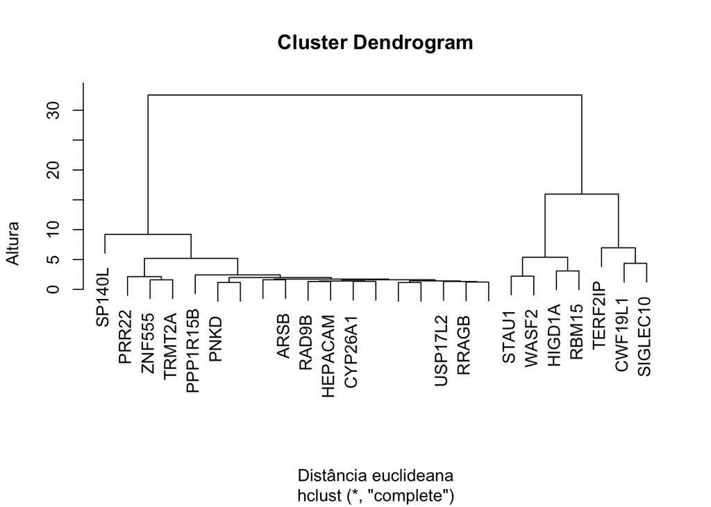

```r
test_agent=rowttests(normalized_exp_filtrado2,"agent")
sign_pvalue_agent=test_agent$p.value<0.01
data_clustering = normalized_exp_filtrado2[sign_pvalue_agent][1:25]
datacluster=exprs(data_clustering)
nomes_agent=rownames(normalized_exp_filtrado2[sign_pvalue_agent])[1:25]
clust_nomes_agent=unlist(mget(nomes_agent, illuminaHumanv4SYMBOL))
rownames(datacluster) <- clust_nomes_agent
dist_euc = dist(datacluster)
cl.hier.complete <- hclust(dist_euc)
plot(cl.hier.complete, xlab="Distância euclideana",ylab="Altura")
```

> Uma representação gráfica dos dados relacionada com o *clustering hierárquico* são os *heatmaps*. Esta permite representar os dados como uma imagem onde cada valor da matriz de dados é representado com uma célula cuja cor varia consoante o valor respetivo, num gradiente de cores que pode ser configurado. Os *heatmaps* tipicamente incluem as árvores criadas por *clustering hierárquico* quer ao nível das linhas, quer ao nível das colunas de dados (Rocha and Ferreira 2017).

```r
heatMapAnalysis(datacluster,c("orange", "blue"))
```

[interactive chart not shown]

> A partir dos resultados do *heatmap*, foi possível verificar que os nossos genes se organizaram em dois *clusters disitintos*, tal como se observou no resultado do *clustering hierárquico*. Assim, é possível deduzir que os genes relativos a cada grupo, de controlo e de tratamento com lítio, apresentam, efetivamente, expressão diferencial.

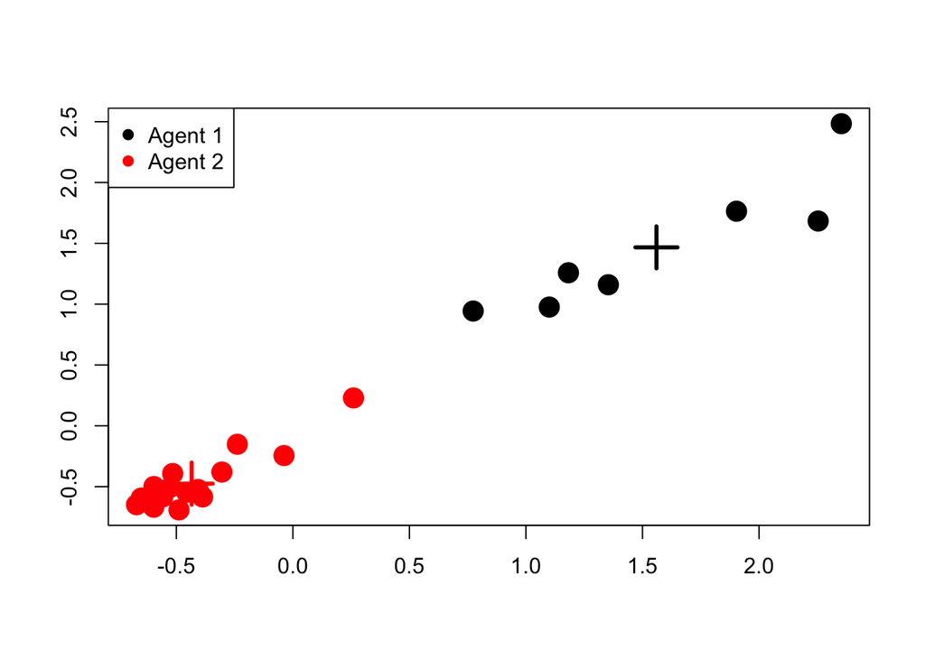

```r
k_means(data_clustering,2,c("Agent 1", "Agent 2"))
```

> O problema de *clustering k-means* constitui uma das possíveis formulações do *clustering*, onde o objetivo é o de minimizar a média do quadrado das distâncias de cada ponto ao centro do *cluster* a que pertence. Assim, prevê-se que um dos grupos esteja mais intimamente ligado que outro. Isso pode também observar-se no *clustering hierárquico*, tendo em consideração as *distâncias euclideanas*.

**Clustering associado ao *other***

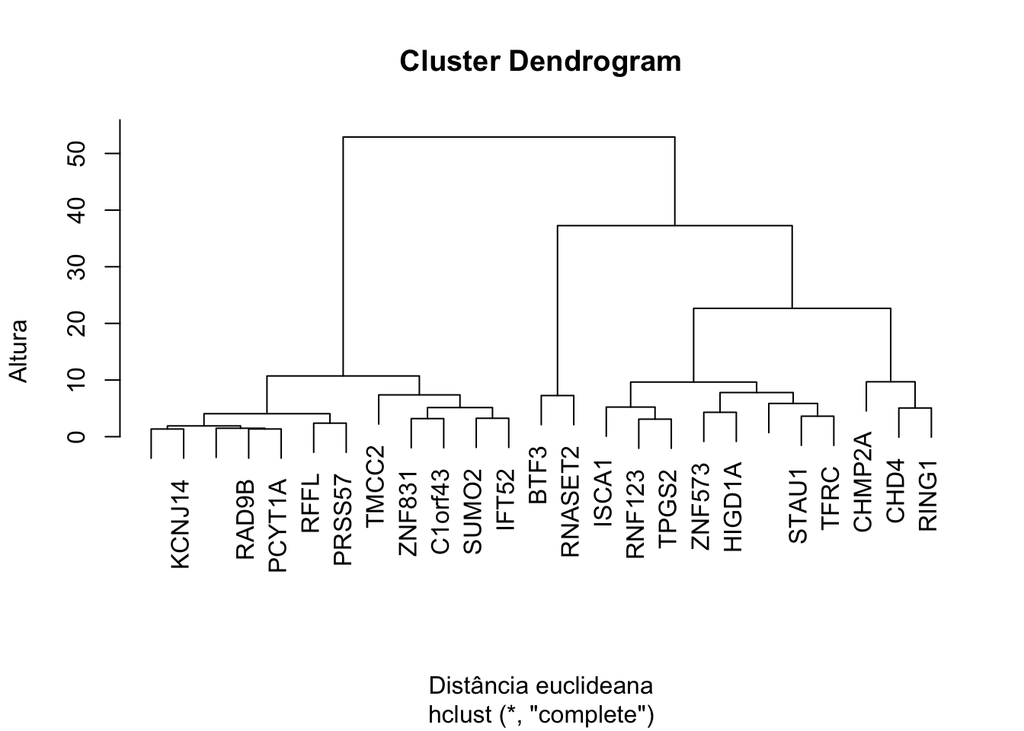

```r
test_other=rowttests(normalized_exp_filtrado2,"other")
sign_pvalue_other=test_other$p.value<0.01
data_clustering2 = normalized_exp_filtrado2[sign_pvalue_other][1:25]
datacluster2=exprs(data_clustering2)
nomes_other=rownames(normalized_exp_filtrado2[sign_pvalue_other])[1:25]
clust_nomes_other=unlist(mget(nomes_other, illuminaHumanv4SYMBOL))
rownames(datacluster2) <- clust_nomes_other
dist_euc = dist(datacluster2)
cl.hier.complete <- hclust(dist_euc)
plot(cl.hier.complete, xlab="Distância euclideana",ylab="Altura")
```

```r
heatMapAnalysis(datacluster2,c("orange", "blue"))
```

[interactive chart not shown]

> A partir dos resultados do *heatmap*, é possível verificar que a distribuição da expressão dos genes de cada um dos grupos não é tão homogénea como se a que se observa no heatmap anterior. Assim, isto pode indiciar que dentro dos genes dos indivíduos que respondem ao tratamento alguns deles podem expressar-se mais intensamente, participando, assim, de forma mais ativa na resposta ao tratamento.

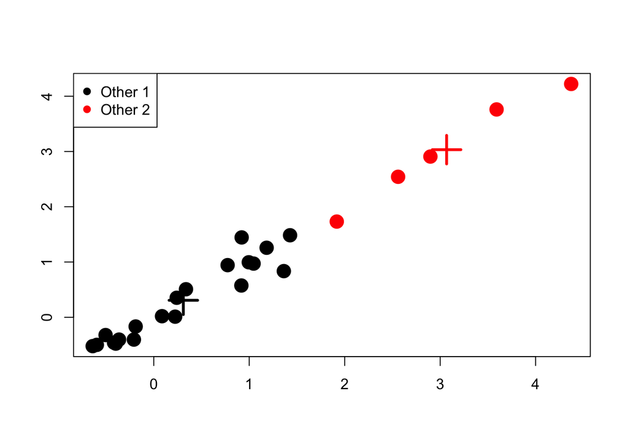

```r
k_means(data_clustering2,2,c("Other 1", "Other 2"))
```

> Tal como se verifica no *heatmap* anterior, a expressão génica dentro dos grupos é pouco homogénea o que sugere que nem todos os genes, que se expressam diferencialmente no que diz respeito a condições de resposta e não resposta, tenham a mesma participação na resposta ao tratamento, sendo previsível a existência de genes sub e sobrexpressos na resposta ao tratamento com lítio.

# 5 Análise Preditiva

## 5.1 *K-nearest Neighbors Algorithm*

**Previsão do tipo de tratamento**

```r
knnResult.agent = MLearn(agent~., normalized_exp_filtrado2, knnI(k = 1), xvalSpec("LOG", 5, balKfold.xvspec(5)))
addmargins(confuMat(knnResult.agent))
```

```
##          predicted
## given     control lithium Sum
##   control      57       7  64
##   lithium      11      45  56
##   Sum          68      52 120
```

```r
precision(knnResult.agent)
```

```
##   control   lithium
## 0.8906250 0.8035714
```

> Aplicando o método de *k-vizinhos mais próximos* ao tipo de tratamento, obteve-se um modelo com precisão de aproximadamente **0.890625** para o tratamento controlo e **0.8035714** para o tratamento com adição de lítio, o que nos indica que o modelo permite fazer previsões com uma precisão bastante razoável para ambos os casos.

**Previsão da resposta ao tratamento**

```r
knnResult.other = MLearn(other ~ ., normalized_exp_filtrado2, knnI(k = 1), xvalSpec("LOG", 5, balKfold.xvspec(5)))
addmargins(confuMat(knnResult.other))
```

```
##                predicted
## given           non-responder responder Sum
##   non-responder            81        13  94
##   responder                 7        19  26
##   Sum                      88        32 120
```

```r
precision(knnResult.other)
```

```
## non-responder     responder
##     0.8617021     0.7307692
```

## 5.2 *Regression Tree*

**Previsão do tipo de tratamento**

```r
treeResult.agent = MLearn(agent~., normalized_exp_filtrado2,rpartI,
                           xvalSpec("LOG", 5, balKfold.xvspec(5)))
addmargins(confuMat(treeResult.agent))
```

```
##          predicted
## given     control lithium Sum
##   control      33      31  64
##   lithium      32      24  56
##   Sum          65      55 120
```

```r
precision(treeResult.agent)
```

```
##   control   lithium
## 0.5156250 0.4285714
```

> Aplicando o método das árvores de regressão à resposta ao tipo de tratamento, obteve-se um modelo com precisão de **0.515625** para o tratamento controlo e **0.4285714** para o tratamento com adição de lítio, indicando que, em ambos os casos, o modelo não permite realizar previsões com confiança.

**Previsão da resposta ao tratamento**

```r
treeResult.other = MLearn(other ~ ., normalized_exp_filtrado2, rpartI, xvalSpec("LOG", 5, balKfold.xvspec(5)))
addmargins(confuMat(treeResult.other))
```

```
##                predicted
## given           non-responder responder Sum
##   non-responder            80        14  94
##   responder                17         9  26
##   Sum                      97        23 120
```

```r
precision(treeResult.other)
```

```
## non-responder     responder
##     0.8510638     0.3461538
```

## 5.3 *Support Vector Machine*

**Previsão do tipo de tratamento**

```r
svmResult.agent <- MLearn(agent~., normalized_exp_filtrado2, svmI, xvalSpec("LOG", 5, balKfold.xvspec(5)))
addmargins(confuMat(svmResult.agent))
```

```
##          predicted
## given     control lithium Sum
##   control      51      13  64
##   lithium      53       3  56
##   Sum         104      16 120
```

```r
precision(svmResult.agent)
```

```
##    control    lithium
## 0.79687500 0.05357143
```

> Aplicando o método das *SVM* à resposta ao tipo de tratamento, obteve-se um modelo com precisão de **0.796875** para o tratamento controlo e **0.0535714** para o tratamento com adição de lítio, isto é, a precisão é bastante razoável para o grupo de controlo mas muito má no caso do grupo tratado com o lítio.

**Previsão da resposta ao tratamento**

```r
svmResult.other = MLearn(other ~ ., normalized_exp_filtrado2, svmI, xvalSpec("LOG", 5, balKfold.xvspec(5)))
addmargins(confuMat(svmResult.other))
```

```
##                predicted
## given           non-responder responder Sum
##   non-responder            90         4  94
##   responder                22         4  26
##   Sum                     112         8 120
```

```r
precision(svmResult.other)
```

```
## non-responder     responder
##     0.9574468     0.1538462
```

> Aplicando o método das *SVM* à resposta à resposta ao tratamento, obteve-se um modelo com precisão de **0.9574468** para os pacientes que não responderam ao tratamento e **0.1538462** para os pacientes que responderam ao tratamento, indicando que o modelo permite fazer previsões excelentes para os pacientes que não responderam ao tratamento, mas com resultados muito pouco fiáveis no caso do grupo que respondeu ao tratamento.

# 6 Conclusão

> Ao longo do decorrer do trabalho, fomo-nos apercebendo das dificuldades que o DataSet escolhido apresentava. O facto de o transtorno bipolar não ser uma doença manifestamente conhecida, tanto a nível de origem como de tratamento, dificultou o processo de interpretação dos resultados obtidos. Em particular, no que diz respeito à análise de expressão diferencial, as dificuldades foram bastantes por não ser totalmente conhecida a forma de atuação do transtorno bipolar no organismo.

> Nos testes de hipóteses realizados concluímos que os genes com maiores diferenças estatísiticas significativas, obtidos para os *t-tests* realizados para os diferentes tipos de tratamento, não foram os mesmos para diferentes tempos experimentais. Isto sugere que, apesar de não ser possível relacionar diretamente estas diferenças com o tratamento com lítio, diferentes tipos de tratamento podem estar relacionados com a variabilidade da expressão de certos genes. Quanto às diferenças de expressão génica dentro de indivíduos que respondem ao tratamento com lítio nas diferentes linhas temporais, verificamos que apenas 5 genes se expressavam de forma efetivamente diferente quando comparamos o tempo inicial do estudo com 1 mês de tratamento. De entre os indivíduos que foram tratados com lítio durante 1 mês, tentou-se então perceber quais os genes que apresentavam as maiores diferenças de expressão quando comparados os indivíduos que respondem e não respondem ao tratamento. A importância incide na possibilidade de que a resposta dos pacientes ao tratamento com lítio possa estar associada à regulação da expressão de alguns genes tornando-os, assim, possíveis alvos para aumentar a eficácia do tratamento. Foi realizada, então, a análise de enriquecimento relativa aos genes de maior significância, a fim de ser possível perceber se estes estariam possivelmente relacionados com a doença. Os resultados obtidos sugerem que a expressão génica pode influenciar na resposta ao tratamento com lítio.

> Quanto ao clustering, conseguimos perceber o claro agrupamento dos genes em dois grupos distintos, no que toca aos atributos dos metadados *agent* e *other*. No entanto, os resultados obtidos no *heatmap* e no *kmeans* indicam que o último atributo apresenta um *cluster* menos homogéneo. Isto pode estar associado ao facto de genes estarem sub e sobreexpressos no que diz respeito à resposta do organismo ao tratamento com lítio. Por fim, quanto à análise preditiva, pode concluir-se que, na maioria dos casos, de entre os métodos de análise preditiva estudados, o método dos *k-vizinhos* mais próximos será o mais adequado para este *DataSet*, uma vez que apresentou boa precisão na previsão de todas as variáveis. No entanto, as *máquinas de vetor de suporte* apresentam resultados excelentes (precisão **>95%**) caso haja interesse em prever quais os pacientes que não vão exibir resposta ao tratamento, o que vai de encontro a um dos objetivos deste estudo: poderá tornar possível determinar quando é preferível utilizar outro tratamento que não a toma de lítio.

Referências

Beech, RD, JJ Leffert, A Lin, LG Sylvia, S Umlauf, S Mane, H Zhao, et al. 2014. “Gene-Expression Differences in Peripheral Blood Between Lithium Responders and Non-Responders in the Lithium Treatment-Moderate Dose Use Study (LiTMUS).” *The Pharmacogenomics Journal* 14 (2). Nature Publishing Group: 182.

Dunning, Mark, Andy Lynch, and Matthew Eldridge. 2015. *IlluminaHumanv4.db: Illumina HumanHT12v4 Annotation Data (Chip IlluminaHumanv4)*.

Karp, Gerald. 2013. *Cell and Molecular Biology*. 7th ed. Wiley.

Rocha, M, and P. G. Ferreira. 2017. *ANÁLISE E EXPLORAÇÃO DE DADOS COM R*. first. FCA.

Schaeffer, E. L., and G. M. Cardillo. 2013. “Efeitos Do Lítio Sobre a Proliferação E a Migração de Neuroblastos Na via Migratória Rostral Em Camundongos Adultos.” http://www.bv.fapesp.br/pt/bolsas/141983/efeitos-do-litio-sobre-a-proliferacao-e-a-migracao-de-neuroblastos-na-via-migratoria-rostral-em-camu/.